# IODS course project

Temesgen

# About the project

*Introduction to open data science course helps students to carry out open and reproducible research. The course covers regression and model validation, clustering and classification, and dimensionality reduction techniques.*

[Link to my Github page](https://github.com/temesgen1858/IODS-project)

# Regression and Model Validation

```r
students2014<-read.table("D:/GitHub/IODS-project/data/learning2014.txt", header=TRUE, sep=",")
str(students2014)
```

```
## 'data.frame':    166 obs. of  7 variables:
##  $ gender  : Factor w/ 2 levels "F","M": 1 2 1 2 2 1 2 1 2 1 ...
##  $ Age     : int  53 55 49 53 49 38 50 37 37 42 ...
##  $ Attitude: int  37 31 25 35 37 38 35 29 38 21 ...
##  $ Points  : int  25 12 24 10 22 21 21 31 24 26 ...
##  $ deep    : num  3.58 2.92 3.5 3.5 3.67 ...
##  $ stra    : num  3.38 2.75 3.62 3.12 3.62 ...
##  $ surf    : num  3.38 2.75 3.62 3.12 3.62 ...
```

```r
dim(students2014)
```

```
## [1] 166   7
```

**Description of the data**

The survey data contains information about approaches and study skills, and attitudes toward statistics.For this exercie, 166 observations of 7 variables are extracted from the ASSIST (Approaches and Study Skills Inventory for Students) and SATS (Survey of Attitudes Toward Statistics) data sources. The variables considered for the survey are age, attitude towards statistics, gender, exam points,and study approaches(deep, startegic and surface).

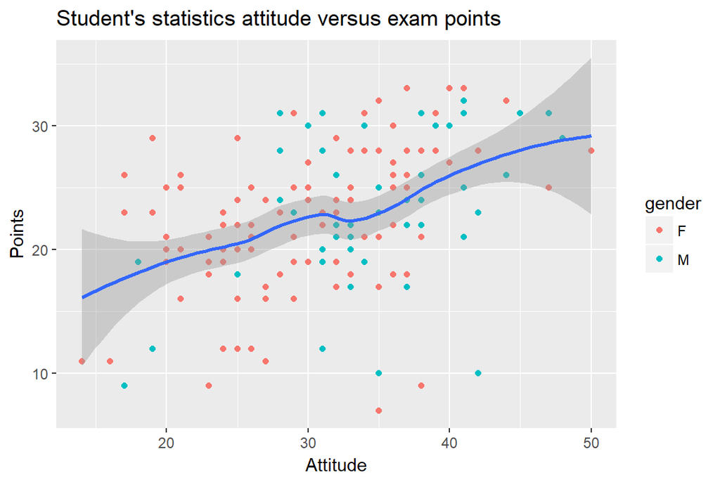

```r
library(ggplot2)
library(dplyr)
df<-students2014

ggplot(df, aes(Attitude, Points)) +
    geom_point(aes(color=gender)) + geom_smooth()+ ggtitle("Student's statistics attitude versus exam points")
```

```r
summary(df$Points)
```

```
##    Min. 1st Qu.  Median    Mean 3rd Qu.    Max.
##    7.00   19.00   23.00   22.72   27.75   33.00
```

```r
summary(df$Age)
```

```
##    Min. 1st Qu.  Median    Mean 3rd Qu.    Max.
##   17.00   21.00   22.00   25.51   27.00   55.00
```

```r
summary(df$Attitude)
```

```
##    Min. 1st Qu.  Median    Mean 3rd Qu.    Max.
##   14.00   26.00   32.00   31.43   37.00   50.00
```

As can be seen from the graph, the data distribution shows an increasing trend and there exists some relationship between attitude and exam point. The relationship is positive and linear, i.e. as the attitude gets better, students results increase. In general, the relation tells us that those students having a good attitude towards statics tend to score good results. `

```r
model=lm(Points~Attitude+Age+stra, data=df)
summary(model)
```

```
##
## Call:
## lm(formula = Points ~ Attitude + Age + stra, data = df)
##
## Residuals:
##      Min       1Q   Median       3Q      Max
## -18.1149  -3.2003   0.3303   3.4129  10.7599
##
## Coefficients:
##             Estimate Std. Error t value Pr(>|t|)
## (Intercept) 10.89543    2.64834   4.114 6.17e-05 ***
## Attitude     0.34808    0.05622   6.191 4.72e-09 ***
## Age         -0.08822    0.05302  -1.664   0.0981 .
## stra         1.00371    0.53434   1.878   0.0621 .
## ---
## Signif. codes:  0 '***' 0.001 '**' 0.01 '*' 0.05 '.' 0.1 ' ' 1
##
## Residual standard error: 5.26 on 162 degrees of freedom
## Multiple R-squared:  0.2182, Adjusted R-squared:  0.2037
## F-statistic: 15.07 on 3 and 162 DF,  p-value: 1.07e-08
```

The regression result (Points = 0.34808xAttitude - 0.08822xAge + 1.00371xStra) show that exam points are related positively to attitude and strategic study approach, while negatively to age. However, summeries of the statistics indicates that only attitude has significant or statistically meaningful relations with exam points, with three star(0.001) showing significant value. For a dependent variable to be statistically significant, p value should be less than or equal to 0.05.Hence age and strategic approach will be removed and the model fit will be run again. Moreover, attitude has a higher t value, meaning it is far by more than six standard deviations from zero and possible to reject the null hypothesis, i.e. we can declare a relationship between Points and Attitude. In addition the standard error is low(round 0.05), meaning the model varies only by 0.05 incase we ran it again and again.

```r
model=lm(Points~Attitude, data=df)
summary(model)
```

```
##
## Call:
## lm(formula = Points ~ Attitude, data = df)
##
## Residuals:
##      Min       1Q   Median       3Q      Max
## -16.9763  -3.2119   0.4339   4.1534  10.6645
##
## Coefficients:
##             Estimate Std. Error t value Pr(>|t|)
## (Intercept) 11.63715    1.83035   6.358 1.95e-09 ***
## Attitude     0.35255    0.05674   6.214 4.12e-09 ***
## ---
## Signif. codes:  0 '***' 0.001 '**' 0.01 '*' 0.05 '.' 0.1 ' ' 1
##
## Residual standard error: 5.32 on 164 degrees of freedom
## Multiple R-squared:  0.1906, Adjusted R-squared:  0.1856
## F-statistic: 38.61 on 1 and 164 DF,  p-value: 4.119e-09
```

The model indicates that for a unit increase in attitude value, the exam points will increase by 0.35 and the relationship is significant. The residul standard error on the other hand shows, how much the model prediction deviates from the actual value, i.e. the exam points can deviate by 5.32 points from the actual value. The F-statistics(38.6) is larger than 1 and thus indicates there is a relationship between value and attitude, and the it’s enough to reject the null hypothesis. The multiple r-squared measure how well the model is fitting the actual data. Meaning, around only 19%(r=0.19) of the variance in the response variable(points) is explained by the predictor varible(attitude). And thus the model has low performance.

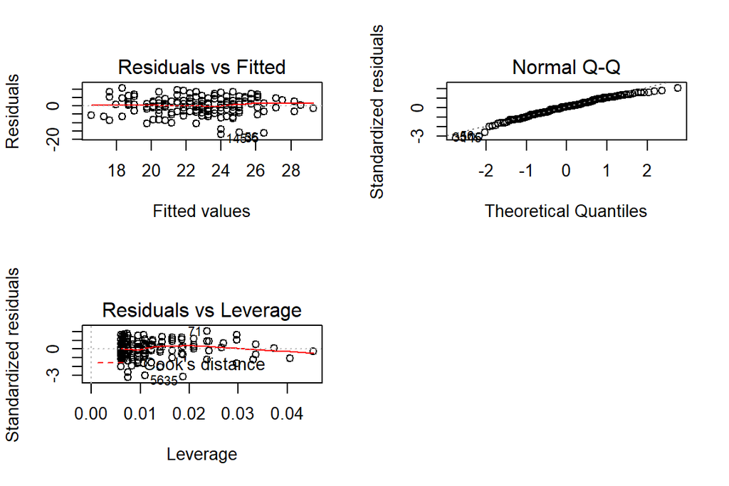

```r
par(mfrow=c(2,2))
plot(model,1)
plot(model,2)
plot(model,5)
```

The normal Q-Q plot shows that the residuals lined up at 45°compared to an ideal normal observations and hence normality assumption of the linear regression holds true. The residuals vs Fitted graph helps to check if the linearity assumption is true. The closer the line to zero,the better the model in meeting linearity assumptions. The residuals, in this case, shows values beyond 2 and -2 standard deviation and thus the linearity assumption needs to be checked. The residual vs leverage result displayed that there is no influential attitude data that can change the slope of the regression model.

title: “Logistic regression”

author: “Temesgen”

date: “November 19, 2017”

output: html_document

# Chapter 3: Logistic regression

*Read data from local folder*

```r
Stud_Alc_Cons <-read.table("D:/GitHub/IODS-project/stu_alc_consu.csv",sep = ";", header = TRUE)
colnames(Stud_Alc_Cons)
```

```
##  [1] "school"     "sex"        "age"        "address"    "famsize"
##  [6] "Pstatus"    "Medu"       "Fedu"       "Mjob"       "Fjob"
## [11] "reason"     "nursery"    "internet"   "guardian"   "traveltime"
## [16] "studytime"  "failures"   "schoolsup"  "famsup"     "paid"
## [21] "activities" "higher"     "romantic"   "famrel"     "freetime"
## [26] "goout"      "Dalc"       "Walc"       "health"     "absences"
## [31] "G1"         "G2"         "G3"         "alc_use"    "high_use"
```

The data set comprised of 382 observations of 35 variables related to the performace of students in two subjects (Mathematics and Portuguese).The data attributes contain information about students grades, demographic, and social(including alcohol consumption) activities. Details of the attributes can be obtained from https://archive.ics.uci.edu/ml/datasets/Student+Performance

*Let’s select 4 variables that have relationship with alcohol consumption and state a hypotheses for each of them*

*Selecetd variables:Grade(G2),absences,studytime,and health*

*Hypothesis(1): with high alcohol consumption, student grade decreases*

*Hypothesis(2): with high alcohol consumption rate, student absence rate increases*

*Hypothesis(3): with high alcohol consumption rate, student study less time*

*Hypothesis(4): with high alcohol consumption rate, student’s health condition deteriorates more*

*Let’s numerically and graphically explore variable distributions and relationships with alcohol consumption*

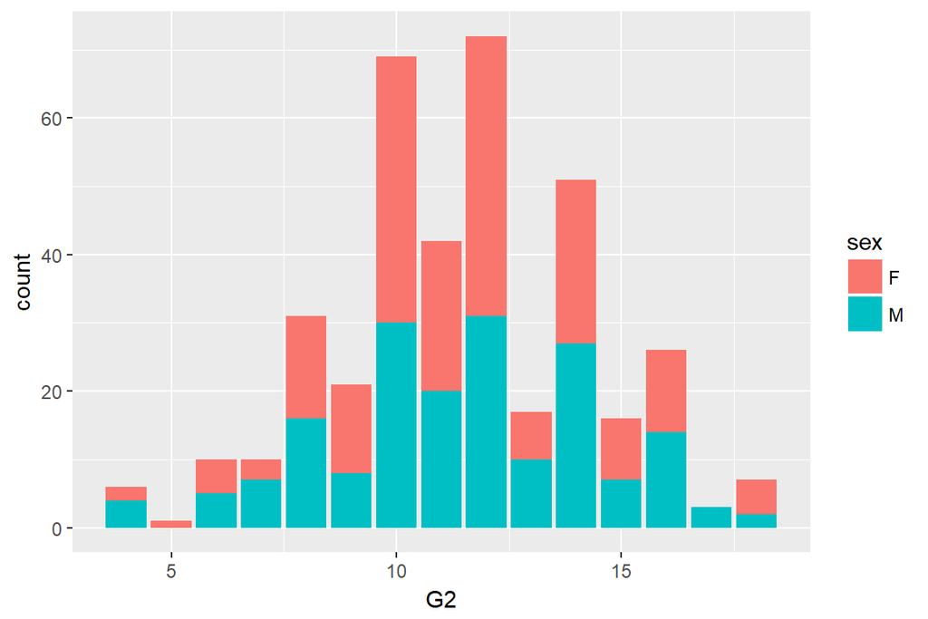

```r
library(dplyr)
library(tidyr)
library(ggplot2)
source("http://pcwww.liv.ac.uk/~william/R/crosstab.r")


g1<- ggplot(data=Stud_Alc_Cons,aes(x=G2,fill=sex))
g1+geom_bar()
```

```r
crosstab(Stud_Alc_Cons, row.vars = "G2", col.vars = "sex", type = "f")
```

```
##     sex   F   M Sum
## G2
## 4         2   4   6
## 5         1   0   1
## 6         5   5  10
## 7         3   7  10
## 8        15  16  31
## 9        13   8  21
## 10       39  30  69
## 11       22  20  42
## 12       41  31  72
## 13        7  10  17
## 14       24  27  51
## 15        9   7  16
## 16       12  14  26
## 17        0   3   3
## 18        5   2   7
## Sum     198 184 382
```

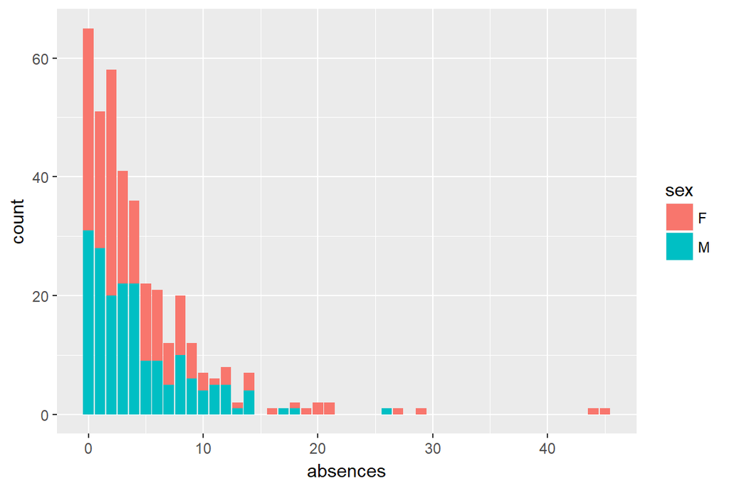

```r
g2<- ggplot(data=Stud_Alc_Cons,aes(x=absences,fill=sex))
g2+geom_bar()
```

```r
crosstab(Stud_Alc_Cons, row.vars = "absences", col.vars = "sex", type = "f")
```

```
##          sex   F   M Sum
## absences
## 0             34  31  65
## 1             23  28  51
## 2             38  20  58
## 3             19  22  41
## 4             14  22  36
## 5             13   9  22
## 6             12   9  21
## 7              7   5  12
## 8             10  10  20
## 9              6   6  12
## 10             3   4   7
## 11             1   5   6
## 12             3   5   8
## 13             1   1   2
## 14             3   4   7
## 16             1   0   1
## 17             0   1   1
## 18             1   1   2
## 19             1   0   1
## 20             2   0   2
## 21             2   0   2
## 26             0   1   1
## 27             1   0   1
## 29             1   0   1
## 44             1   0   1
## 45             1   0   1
## Sum          198 184 382
```

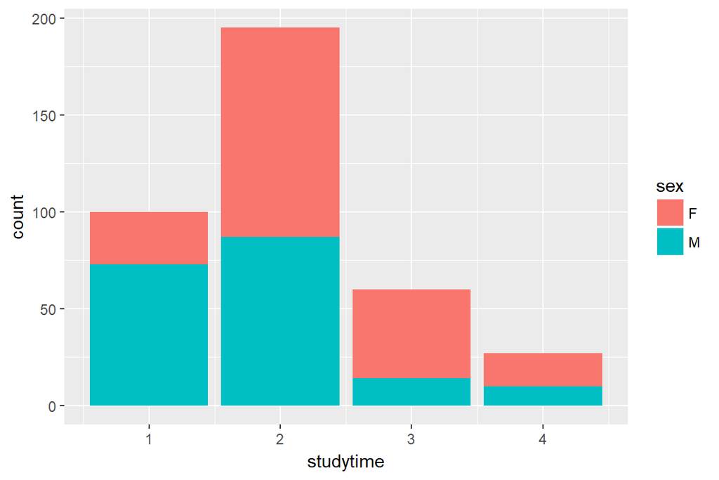

```r
g3<- ggplot(data=Stud_Alc_Cons,aes(x=studytime,fill=sex))
g3+geom_bar()
```

```r
crosstab(Stud_Alc_Cons, row.vars = "studytime", col.vars = "sex", type = "f")
```

```
##           sex   F   M Sum
## studytime
## 1              27  73 100
## 2             108  87 195
## 3              46  14  60
## 4              17  10  27
## Sum           198 184 382
```

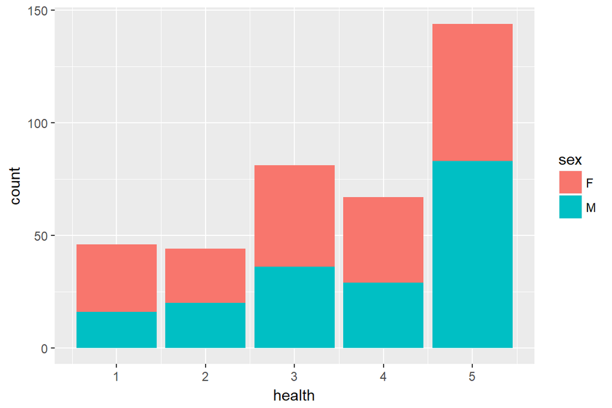

```r
g4<- ggplot(data=Stud_Alc_Cons,aes(x=health,fill=sex))
g4+geom_bar()
```

```r
crosstab(Stud_Alc_Cons, row.vars = "health", col.vars = "sex", type = "c")
```

```
##        sex      F      M
## health
## 1           15.15   8.70
## 2           12.12  10.87
## 3           22.73  19.57
## 4           19.19  15.76
## 5           30.81  45.11
## Sum        100.00 100.00
```

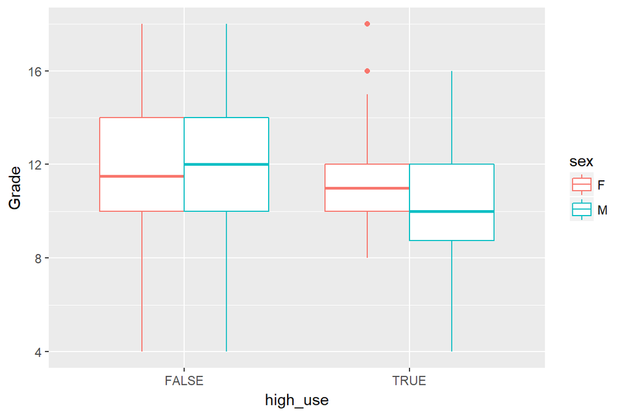

```r
g5<-ggplot(data=Stud_Alc_Cons,aes(x=high_use,y=G2,col=sex))
g5+geom_boxplot()+ylab("Grade")
```

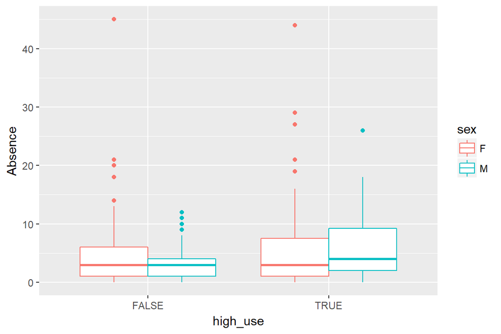

```r
g6<-ggplot(data=Stud_Alc_Cons,aes(x=high_use,y=absences,col=sex))
g6+geom_boxplot()+ylab("Absence")
```

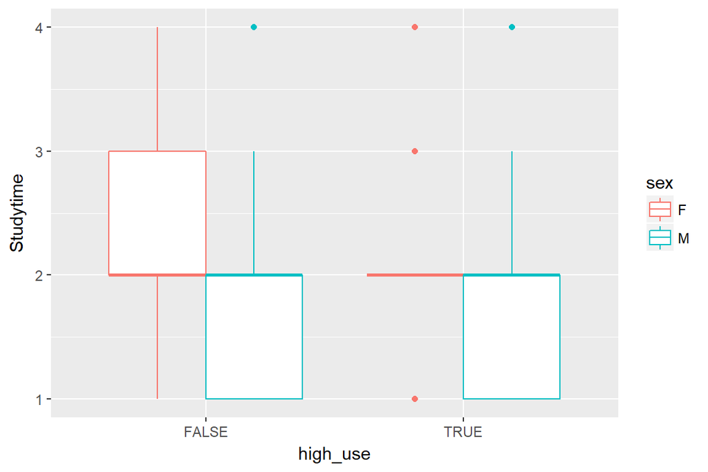

```r
g7<-ggplot(data=Stud_Alc_Cons,aes(x=high_use,y=studytime,col=sex))
g7+geom_boxplot()+ylab("Studytime")
```

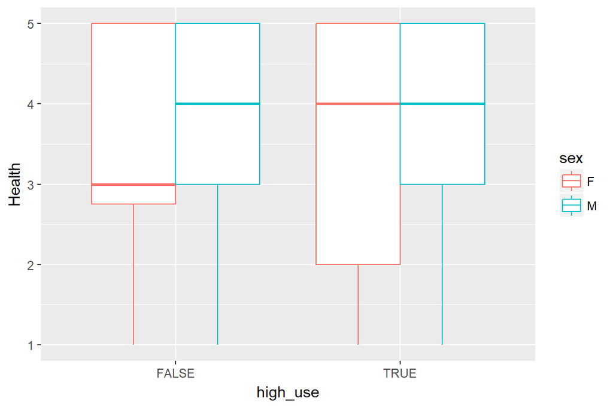

```r
g8<-ggplot(data=Stud_Alc_Cons,aes(x=high_use,y=health,col=sex))
g8+geom_boxplot()+ylab("Health")
```

*Regarding their relationship with alcohol use, the result indicates that with high alcohol use the grades for both female and male students decreases. The decline in grade is, however, more significant for male students than female. The overall result agrees well with the hypothesis stated above*

*With high rate of alcohol consumption, the number of absent male students is higher than those with low consumption. Where as for female students, the rate of alcohol consumption have no effect, i.e. the median value remain the same for both high and low consumption. Therefore the hypothesis holds true only for male students*

*The resut showed that alcohol consumption rate has no impact on the studytime for both male and female student. Thus, the hypothesis is not true*

*The result show that with high alcohol consumption, female student’s health consitions shows improvement; wheras for male students, it has no effect. Hence, the hypotheis stated above is not true based on the results obtained*

```r
m <- glm(high_use ~ G2 + absences + studytime + health , data = Stud_Alc_Cons, family = "binomial")

# print out a summary of the model
summary(m)
```

```
##
## Call:
## glm(formula = high_use ~ G2 + absences + studytime + health,
##     family = "binomial", data = Stud_Alc_Cons)
##
## Deviance Residuals:
##     Min       1Q   Median       3Q      Max
## -2.2480  -0.8409  -0.6671   1.1501   2.1433
##
## Coefficients:
##             Estimate Std. Error z value Pr(>|z|)
## (Intercept)  0.16859    0.67673   0.249 0.803263
## G2          -0.05673    0.04275  -1.327 0.184510
## absences     0.07714    0.02277   3.388 0.000705 ***
## studytime   -0.50762    0.15776  -3.218 0.001292 **
## health       0.06586    0.08565   0.769 0.441984
## ---
## Signif. codes:  0 '***' 0.001 '**' 0.01 '*' 0.05 '.' 0.1 ' ' 1
##
## (Dispersion parameter for binomial family taken to be 1)
##
##     Null deviance: 465.68  on 381  degrees of freedom
## Residual deviance: 431.02  on 377  degrees of freedom
## AIC: 441.02
##
## Number of Fisher Scoring iterations: 4
```

```r
# print out the coefficients of the model
coef(m)
```

```
## (Intercept)          G2    absences   studytime      health
##  0.16859162 -0.05672664  0.07714152 -0.50761582  0.06585520
```

```r
#print out the odd ration from coefficients of the model
ODR <- coef(m) %>% exp
ODR
```

```
## (Intercept)          G2    absences   studytime      health
##   1.1836367   0.9448523   1.0801949   0.6019290   1.0680720
```

```r
# compute confidence intervals (CI)
CI <- confint(m) %>% exp
cbind(ODR, CI)
```

```
##                   ODR     2.5 %    97.5 %
## (Intercept) 1.1836367 0.3128835 4.4745202
## G2          0.9448523 0.8683014 1.0271840
## absences    1.0801949 1.0352601 1.1321335
## studytime   0.6019290 0.4377247 0.8135916
## health      1.0680720 0.9041860 1.2660080
```

*The result shows that absences from class and studytime have significant relationship with the probability of alcohol consumption rate, while health and grade(G2) do not. Being absent from class has a positive relationship whereas studytime has negative relation with the probality of alcohol consumption rate, i.e.a unit increase in absence increases the probability of high alcohol consumption by 0.07714, while a unit increase in study time decreases the probability of high alcohol consumption by 0.50762*

```r
#let's drop statistically insignificant variables and rebuild the model uisng absences and studytime
m1 <- glm(high_use ~  absences + studytime , data = Stud_Alc_Cons, family = "binomial")
summary(m1)
```

```
##
## Call:
## glm(formula = high_use ~ absences + studytime, family = "binomial",
##     data = Stud_Alc_Cons)
##
## Deviance Residuals:
##     Min       1Q   Median       3Q      Max
## -2.2128  -0.8387  -0.7046   1.1996   2.1832
##
## Coefficients:
##             Estimate Std. Error z value Pr(>|z|)
## (Intercept) -0.16640    0.33954  -0.490 0.624087
## absences     0.08054    0.02285   3.524 0.000425 ***
## studytime   -0.55015    0.15550  -3.538 0.000403 ***
## ---
## Signif. codes:  0 '***' 0.001 '**' 0.01 '*' 0.05 '.' 0.1 ' ' 1
##
## (Dispersion parameter for binomial family taken to be 1)
##
##     Null deviance: 465.68  on 381  degrees of freedom
## Residual deviance: 433.65  on 379  degrees of freedom
## AIC: 439.65
##
## Number of Fisher Scoring iterations: 4
```

```r
# predict the probability of high_use
probabilities <- predict(m1, type = "response")

# add the predicted probabilities to 'Stud_Alc_Cons'
Stud_Alc_Cons <- mutate(Stud_Alc_Cons, probability = probabilities)

# use the probabilities to make a prediction of high_use
Stud_Alc_Cons <- mutate(Stud_Alc_Cons, prediction = probability>0.5)

# see the last fifteen original classes, predicted probabilities, and class predictions
select(Stud_Alc_Cons, studytime,absences, high_use, probability, prediction) %>% tail(15)
```

```
##     studytime absences high_use probability prediction
## 368         2        0    FALSE   0.2198228      FALSE
## 369         2       14     TRUE   0.4652873      FALSE
## 370         2        4     TRUE   0.2799880      FALSE
## 371         1        2    FALSE   0.3645990      FALSE
## 372         2        3    FALSE   0.2640419      FALSE
## 373         1        0    FALSE   0.3281537      FALSE
## 374         1        7     TRUE   0.4618903      FALSE
## 375         3        1    FALSE   0.1497827      FALSE
## 376         1        6    FALSE   0.4419431      FALSE
## 377         3        2    FALSE   0.1603317      FALSE
## 378         2        2    FALSE   0.2486902      FALSE
## 379         2        2    FALSE   0.2486902      FALSE
## 380         2        3    FALSE   0.2640419      FALSE
## 381         1        4     TRUE   0.4026660      FALSE
## 382         1        2     TRUE   0.3645990      FALSE
```

```r
# provide 2x2 cross tabulation of the prediction and actual values
table(high_use = Stud_Alc_Cons$high_use, prediction = Stud_Alc_Cons$prediction )
```

```
##         prediction
## high_use FALSE TRUE
##    FALSE   256   12
##    TRUE     96   18
```

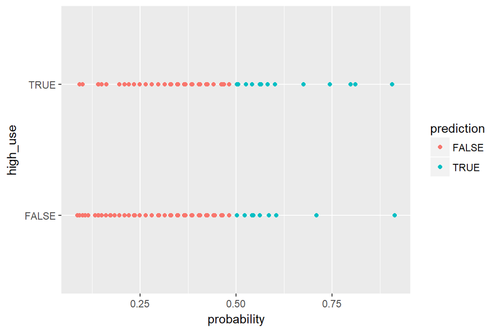

```r
# Display graphically
m <- ggplot(Stud_Alc_Cons, aes(x = probability, y=high_use, col=prediction))

# define the geom as points and draw the plot
m+geom_point()
```

```r
# calculate training error
loss_func <- function(class, prob) {
  n_wrong <- abs(class - prob) > 0.5
  mean(n_wrong)
}


loss_func(class = Stud_Alc_Cons$high_use, prob = Stud_Alc_Cons$probability)
```

```
## [1] 0.2827225
```

*The resut shows that the model error is 0.28, which means the model can commit a pediction error of about 28%*

```r
# performing 10-fold cross validation
library(boot)
cros_val <- cv.glm(data = Stud_Alc_Cons, cost = loss_func, glmfit = m1, K = 10)

# average number of wrong predictions in the cross validation
cros_val$delta[1]
```

```
## [1] 0.2879581
```

*The prediction error is 0.28. Hence, I didn’t find a better model compared to the model in the DataCamp*

title: “Clustering and classification”

author: “Temesgen”

date: “November 25, 2017”

output: html_document